# Final Orca Data Project (including old hypothesis)

# Plotting

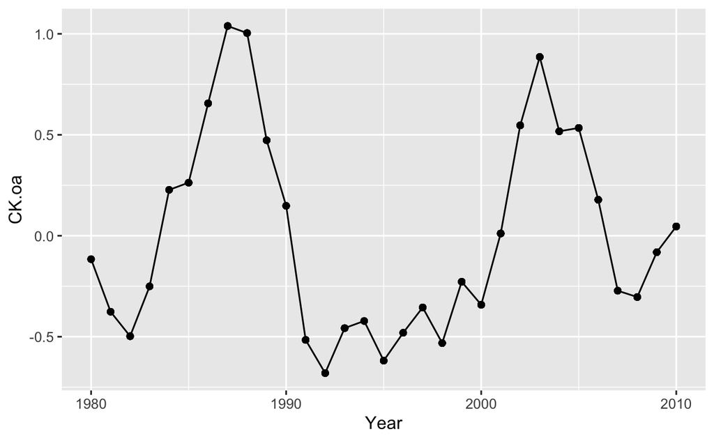

```r
# Looking at how salmon changes over time
ggplot(orca_data_sub2, aes(Year, CK.oa))+
  geom_point()+
  geom_line()
```

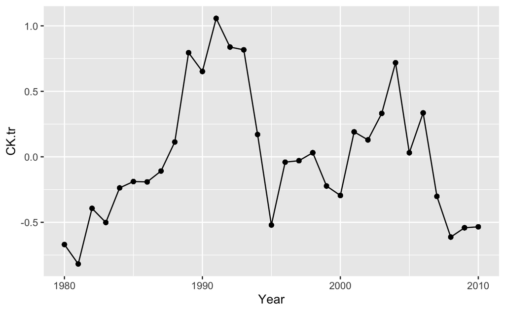

```r
ggplot(orca_data_sub2, aes(Year, CK.tr))+
  geom_point()+
  geom_line()
```

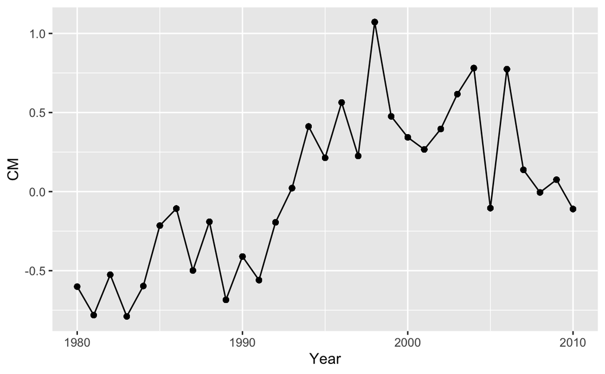

```r
ggplot(orca_data_sub2, aes(Year, CM))+
  geom_point()+
  geom_line()
```

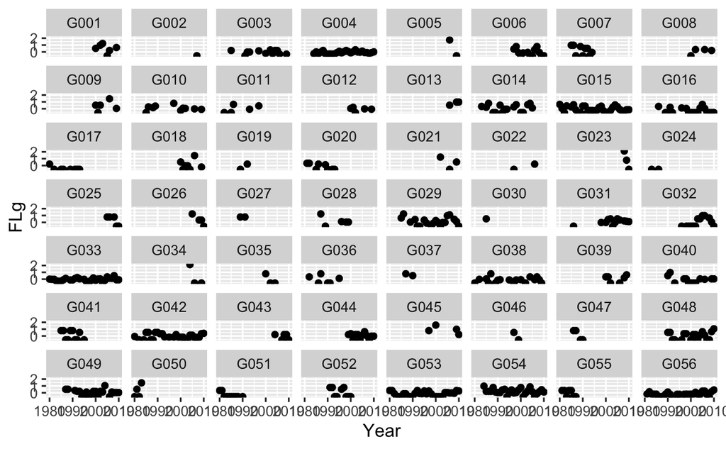

```r
# Lactating females over time in pods
ggplot(orca_data_sub2, aes(Year, FLg))+
  geom_point()+
  facet_wrap(~Group.ID)
```

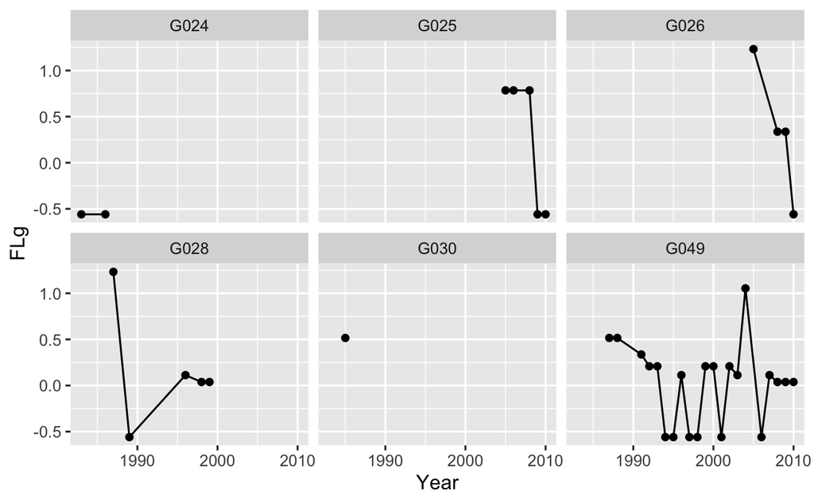

```r
ggplot(orca_data_sub2_6, aes(Year, FLg))+
  geom_point()+
  geom_line()+ #improves readability
  facet_wrap(~Group.ID)
```

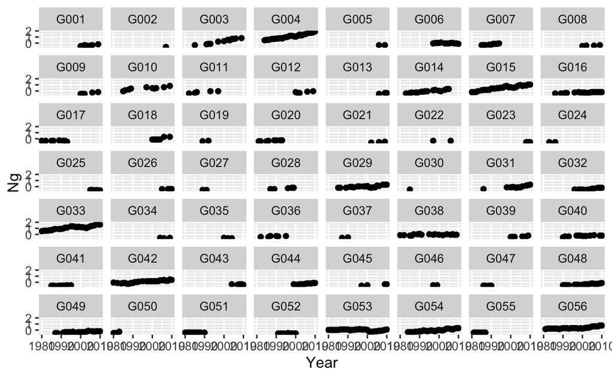

```r
# Number of individuals in pods
ggplot(orca_data_sub2, aes(Year, Ng))+
  geom_point()+
  facet_wrap(~Group.ID)
```

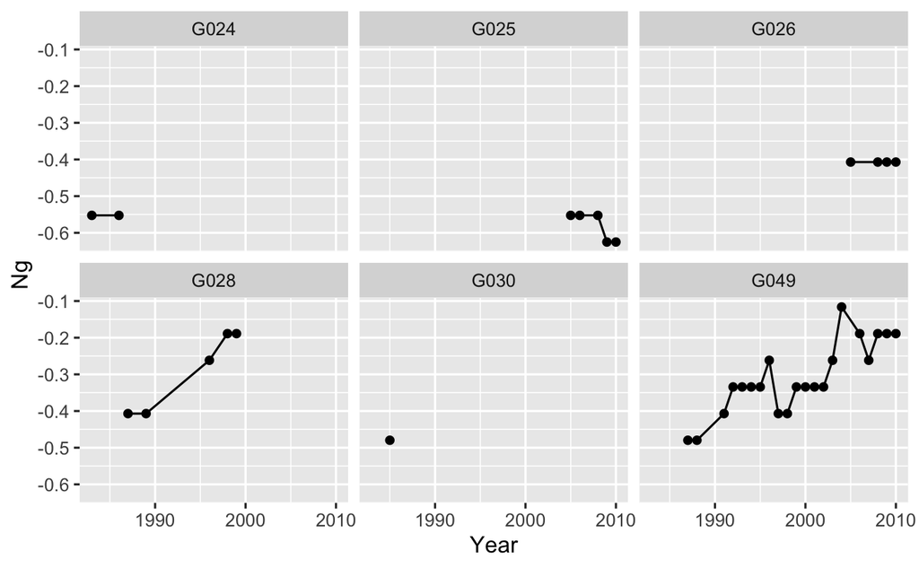

```r
ggplot(orca_data_sub2_6, aes(Year, Ng))+
  geom_point()+
  geom_line()+
  facet_wrap(~Group.ID)
```

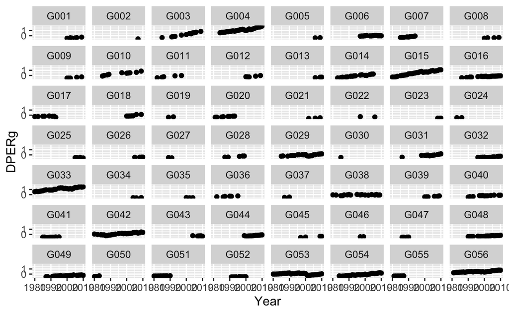

```r
# Pod energetic requirement
ggplot(orca_data_sub2, aes(Year, DPERg))+
  geom_point()+
  facet_wrap(~Group.ID)
```

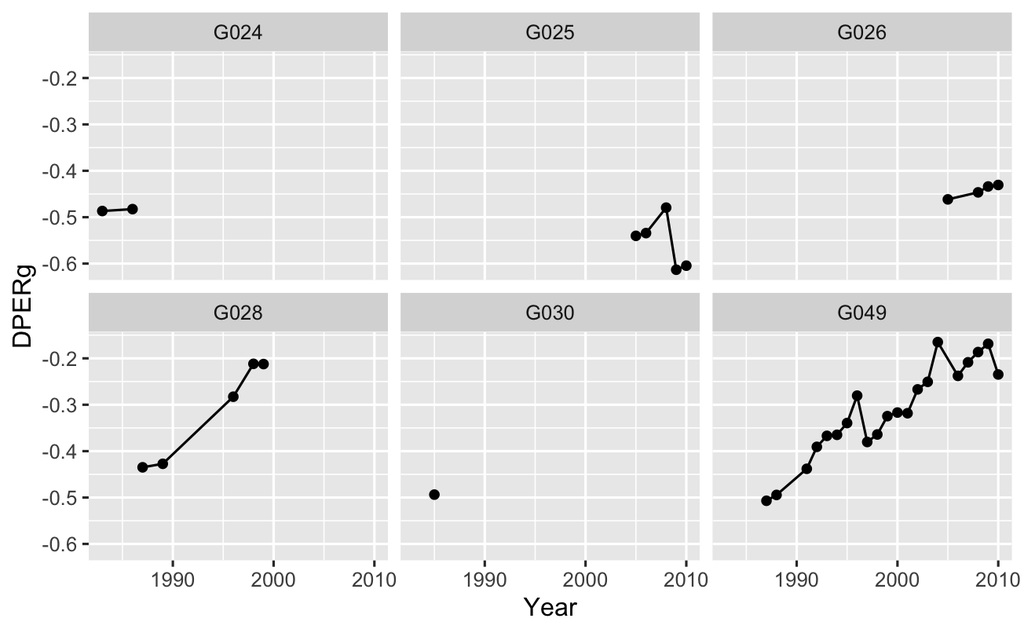

```r
ggplot(orca_data_sub2_6, aes(Year, DPERg))+
  geom_point()+
  geom_line()+
  facet_wrap(~Group.ID)
```

## Testing Normality

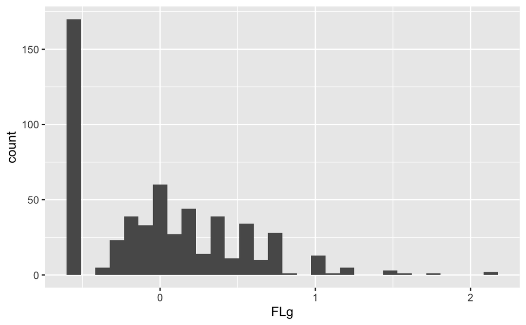

```r
ggplot(orca_data_sub2, aes(FLg))+
  geom_histogram() #histogram of FLg to assess normality
```

## Unscaling

```r
# value = x-mean(x) / 2sd(x)
# descale <- function(x, sd){
#   vals <- c()
#   for(i in 1:length(x)){
#     vals[i] <- (x[i]+mean(x))*(2*sd)
#     # The authors subtr
#   }
#   return(vals)
# }
#
#
# unscaledFLg <- descale(orca_data_sub2$FLg, 0.73)
#
# unscaledData <- orca_data_sub2 %>%
#   select(FLg) %>%
#   unscale()
#
# unscaledFLg <- unscale(2*orca_data_sub2$FLg)
# unscaledCK.oa <- unscale(2*orca_data_sub2$CK.oa)
```

# Testing Assumptions (LMM)

1. Random Effects are Normally Distributed
2. Response (lactating Females) is normally distributed
3. Homogenity/Homoscedasticity of variance

Testing 1. Random Effects Normally distributed

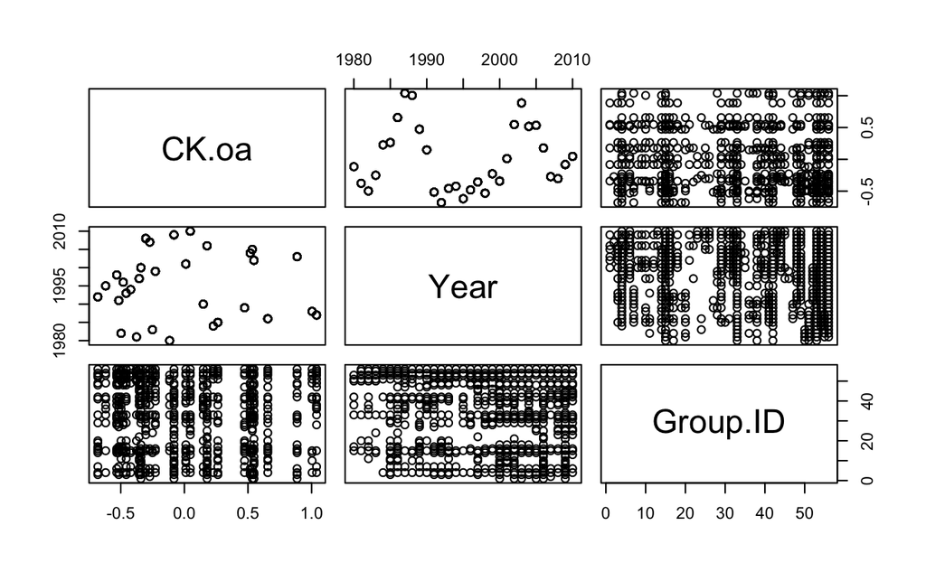

```r
orca_data_sub2 %>%
  select(CK.oa, Year, Group.ID) %>%
  plot()
```

```r
orca_data_sub2 %>%
  select(CK.oa) %>%
  summary()
```

```
     CK.oa
 Min.   :-0.68030
 1st Qu.:-0.35512
 Median :-0.08173
 Mean   : 0.02821
 3rd Qu.: 0.47299
 Max.   : 1.03896
```

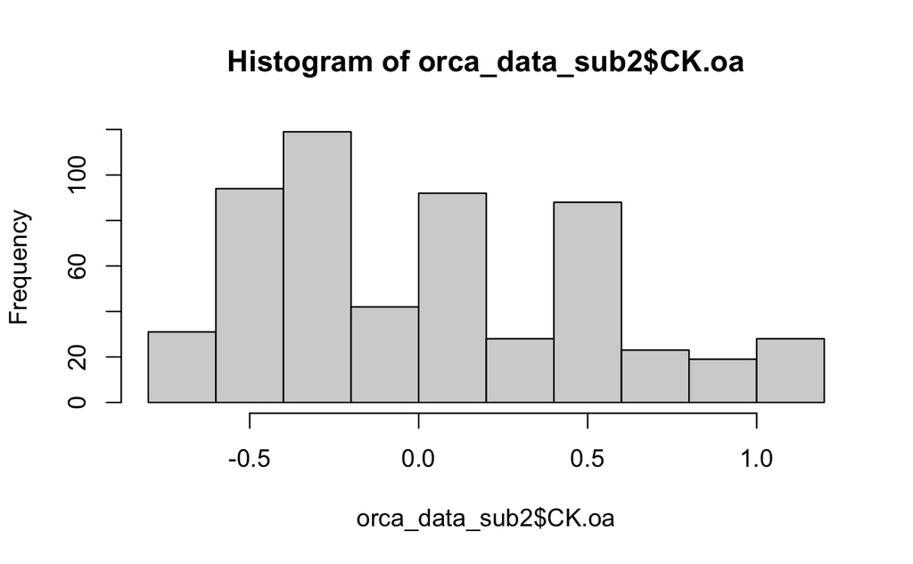

```r
hist(orca_data_sub2$CK.oa)
```

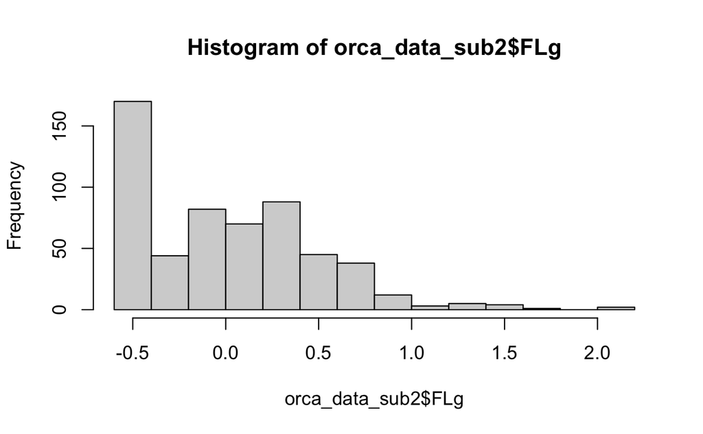

```r
hist(orca_data_sub2$FLg) #Y is not normally distributed Transform to log?
```

# Making our Linear Model

Model #1 Treat Salmon Data as a fixed Variable. For the sake of just exploration we’re going to use just CK.oa for now

Random Variables; Year, Group ID, Fixed Variables : FLg, Salmon Data

## LMM with Randomized Slope

- we have random effects
- data is dependent on one another
- our data is not normal
- we expect the number of salmon to increase ‘randomly’ with number of lactating females

# CK.oa and FLg- simplest model just year as random effect

```r
library(lme4)
library(lmerTest)
CK_FLg_Year<-lmer(FLg~CK.oa+ (1|Year), data = orca_data_sub2, REML= FALSE)
summary (CK_FLg_Year)
```

[output not shown]

**BIGNOTE** We don’t actually know what units the salmon data is in so this is hard to interpret

#CK.Oa, FLG ; Random effects: year and Group ID

```r
CK_FLg_Year_GroupID<-lmer(FLg~CK.oa + (1|Year) + (1|Group.ID),
                          data = orca_data_sub2, REML= FALSE)
summary(CK_FLg_Year_GroupID)
```

```
Linear mixed model fit by maximum likelihood . t-tests use Satterthwaite's method ['lmerModLmerTest']
Formula: FLg ~ CK.oa + (1 | Year) + (1 | Group.ID)
   Data: orca_data_sub2

     AIC      BIC   logLik deviance df.resid
   812.5    834.2   -401.2    802.5      559

Scaled residuals:
    Min      1Q  Median      3Q     Max
-1.8742 -0.8946 -0.0392  0.6694  4.1164

Random effects:
 Groups   Name        Variance Std.Dev.
 Group.ID (Intercept) 0.019236 0.13869
 Year     (Intercept) 0.008193 0.09051
 Residual             0.223870 0.47315
Number of obs: 564, groups:  Group.ID, 56; Year, 31

Fixed effects:
            Estimate Std. Error       df t value Pr(>|t|)
(Intercept)  0.02251    0.03430 29.40355   0.656    0.517
CK.oa        0.07104    0.05411 32.35757   1.313    0.198

Correlation of Fixed Effects:
      (Intr)
CK.oa -0.039
```

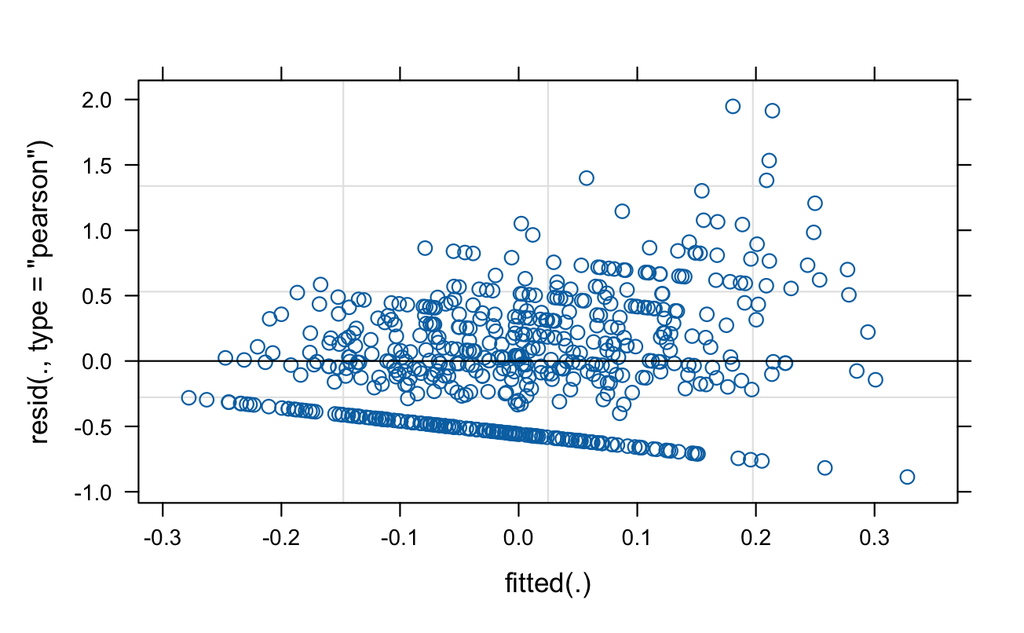

```r
plot(CK_FLg_Year_GroupID) # I dont know
```

We attempted to transform this plot just to see if anything made more sense

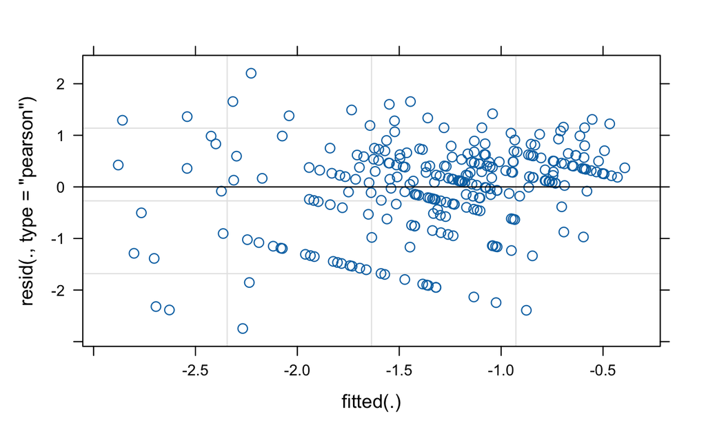

```r
# log transforming FLG
orca_data_sub2$FLg <- log(orca_data_sub2$FLg)
CK_FLg_Year_GroupID_logtransform<-lmer(FLg~CK.oa + (1|Year) + (1|Group.ID),
                                       data = orca_data_sub2, REML= FALSE)
#looks better!
plot(CK_FLg_Year_GroupID_logtransform)
```

```r
#exponentially transforming FLG
orca_data_sub2$FLg <- exp(orca_data_sub2$FLg)


CK_FLg_Year_GroupID_exptransform<-lmer(FLg~CK.oa + (1|Year) + (1|Group.ID),
                                       data = orca_data_sub2, REML= FALSE)
```

```
boundary (singular) fit: see help('isSingular')
```

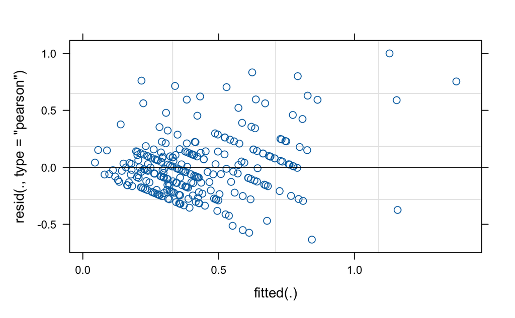

```r
#this also looks somewhat better than the original but I think the log one
# is a better transformation
plot(CK_FLg_Year_GroupID_exptransform)
```

# Data Generation

For each year from 1980 to 2010 need to randomly select a salmon quantity. Hypothetically, the abundance would go down towards the 2000’s but for this beginning function I’m just gonna have it choose randomly.

## Creating each generator individually

### Chum Generator

This data is generated based on salmon data collection from https://www.npafc.org/wp-content/uploads/Public-Documents/2009/1199Rev1WGSA.pdf pg 51 (BC Chum Salmon) From 1980 - 2008 (in millions of fish): Min value: 0.46 (million) Max Value: 6.17 (million)

```r
years_measured<-(c(seq(1980,2010,1)))
# Values are in of millions of fish
chum_generator <- function(){
  # Choosing a random value between the range of 0.46 to 6.17,
  # replacement is true
  chum_abundance <- sample(x = seq(0.46,6.17,0.02),
                         size = length(years_measured),
                         replace = T)
  # Making data frame for each year and with the random density
  yearly_chum <- data.frame(years_measured, chum_abundance)
    return(yearly_chum)
  }
```

### Chinook Generator

Based on https://www.npafc.org/wp-content/uploads/Public-Documents/2009/1199Rev1WGSA.pdf pg 123 From 1980 - 2008 (in millions of fish) Min value: 0.13 Max Value: 1.27

```r
#Numbers are in values of Millions of Fish
chinook_generator <- function(){
  # choosing a random value between the range of 0.46 to 6.17,
  # replacement is True
  chinook_density <- sample(x = seq(0.13,1.27,0.02),
                            size = length(years_measured),
                            replace = T)
  # making data frame for each year and with the random density
  yearly_chinook <- data.frame(years_measured, chinook_density)
    return(yearly_chinook)
  }

chinook_generator()
```

| years_measured | chinook_density |
| --- | --- |
| 1980 | 0.33 |
| 1981 | 1.01 |
| 1982 | 0.99 |
| 1983 | 0.85 |
| 1984 | 0.13 |
| 1985 | 0.77 |
| 1986 | 0.15 |
| 1987 | 0.15 |
| 1988 | 0.83 |
| 1989 | 0.25 |

[output cut: 21 more lines]

### Generator for Salmon in DF format

We needed to change the format so we could combine our data into one data frame and graph it as a histogram.

```r
salmon <- data.frame(chinook_generator(), chum_generator())

salmon_data<-salmon %>%
  select(years_measured,chinook_density,chum_density) %>%
  mutate(total_salmon = chinook_density + chum_density)
```

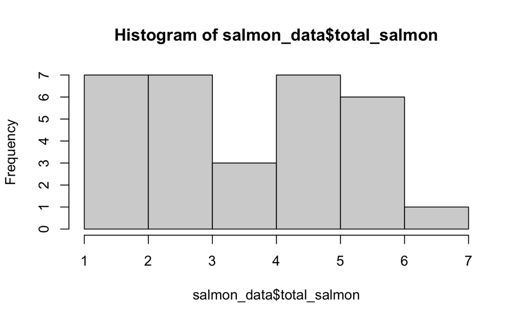

```r
hist(salmon_data$total_salmon)
```

### Pod Size Generator

Based on information from https://media.fisheries.noaa.gov/dam-migration/2019_sars_alaska_killer_whale_-_eastern_north_pacific_northern_resident.pdf Approximate Total Population: ~300 Typical Pod Count: ~16

```r
# Create groups 1-16
group_number<-seq(1,16,1)

pod <- function(){
  # Allow total number of orcas to vary each year
  n <- rpois(1, lambda = 300)
  pod_size < -rmultinom(1, size = n, prob = rep(1,16))
  # Multinomial to create 16 pods of total n orcas
  pod_size_by_group <- data.frame(group_number, pod_size)
  # Putting the values in dataframe
  return(pod_size_by_group)
}
```

### Amount of Reproductive females

Based on www.sararegistry.gc.ca/status/status_e.cfm

```r
pod_data<- pod() %>%
  mutate(number_repro_females = round(pod_size * 0.22,0))
#rounding upwards to get whole number
```

### Number of Lactating Females

This ultimately was not used in the final generator. The chance a reproductive age female orca had a child in a given year was reported as 20% in a CBC article. However this ignored any effects of salmon, which we needed to include.

```r
Lactating_females <- c()
for(i in 1:nrow(pod_data)){
  Lactating_females[i] <- rbinom(1,pod_data$number_repro_females[i], prob = 0.2)
}

pod_data_2<-pod_data %>%
  mutate(Lactating_females = Lactating_females)
```

## Final Data Generator

```r
data_Gen <- function(beta1, beta2){
  pod_data_Year <- data.frame()

  #Salmon Data
  #generate salmon data in a dataframe
  salmon <- data.frame(chinook_generator(), chum_generator())

  salmon_data<-salmon %>%  #format data frame, add total salmon
    select(years_measured,chinook_density,chum_density) %>%
    mutate(total_salmon = chinook_density + chum_density)

  #fitting the salmon data to the orca data
  rep_salmon_data <- data.frame(chinook_density = c(),
                                chum_density = c(),
                                total_salmon = c())

  # Setting the counters to one
  x <- 1
  i <- 1
  # Go through the number rows of the orca data
  while(x < 496){
    #for each 16 rows of an empty data frame, add the corresponding year
    #from salmon data
    rep_salmon_data[c(x:(x+16)),1] <- salmon_data[i,2]
    rep_salmon_data[c(x:(x+16)),2] <- salmon_data[i,3]
    rep_salmon_data[c(x:(x+16)),3] <- salmon_data[i,4]
    x <- x+16 #increase rows in repeated salmon data
    i <- i+1 #increase row in salmon data
  }
  #remove a repeated final column
  rep_salmon_data <- rep_salmon_data[-c(497),]

  # Add column names
  colnames(rep_salmon_data) <- c("chinook_abundace",
                                 "chum_abundance",
                                 "total_salmon")

  # Orca Data Generation
  group_number<-seq(1,16,1) #each pod is given a number
  n <- 31 #total number of years (1980-2010)

  # generating pods for each year
  for(i in 1:n){
    pod <- function(){
      #poisson distribution to choose total population each year
      s <- rpois(1, lambda = 300)
      #multinomial distribution keeps orcas at total pop size, make 16 pods
      pod_size <- rmultinom(1, size = s, prob = rep(1,16))
      year <- i+1979
      pod_size_by_group <- data.frame(year, group_number, pod_size)
      return(pod_size_by_group)
    }

    # Generating lactating females
    pod_data <- pod() # Call pod function above to make pods
    Lactating_females <- c() # Create a vector to hold lactating females

    # Calculate lactating females
    for(i in 1:nrow(pod_data)){
      # Betas - makes lactating females dependent on salmon + pod size
      Lactating_females[i] <- rpois(1,
                                lambda = beta1*(pod_data$pod_size[i])+
                                         beta2*rep_salmon_data$total_salmon[i])
      # so: determine lactating females from pod size + additional amount
      # w/ more salmon
    }
    # Add lactating females column
    pod_data_2 <- pod_data %>%
      mutate(lactating_females = Lactating_females)

    # Bind data frames to an overall data frame
    pod_data_Year <- rbind(pod_data_Year, pod_data_2)
  }

  # Combining the dataframe
  gen_Data <- pod_data_Year %>%
    # Add the salmon columns
    mutate(chinook_abundance = c(rep_salmon_data[,1])) %>%
    mutate(chum_abundance = c(rep_salmon_data[,2])) %>%
    mutate(total_salmon = c(rep_salmon_data[,3]))

  return(gen_Data)
}
```

# Power Analysis

```r
# Set parameters
params <- expand.grid(beta1 = seq(0.2,0.24,0.01),
                      beta2 = c(0.0000001,0.00001,0.0001,0.001,0.01,0.1))

# Beta needs to be a vector with two entries - 1st: beta1, 2nd: beta2
power_poisson <- function(beta){
  # Number of models to create for each set of parameters
  sims <- 10

  # Create vectors/variables to hold values
  pValSalmon <- c()
  pValPod <- c()
  SalmonEffect <- c()
  PodEffect <- c()
  models <- NULL
  predictions <- NULL
  Intercept <- c()

  # Loop for the number of simulations
  for(i in 1:sims){
    # Generate the orca data for 31 years (1980-2010)
    data <- data_Gen(beta[1], beta[2])
    # Make a glmm with lactating females as (y), and fixed effects total_salmon
    # and pod_size as (x). Random effects are year and group_number
    model <- glmer(lactating_females~total_salmon+pod_size+
                   (1|group_number)+(1|year),
                 family = poisson, data)
    models[[i]] <- model # Saving the models to return if needed

    # Predict the number of lactating females from the model, and save the
    # total salmon, year, pod_size, group_number, and model index
    predictions[[i]] <- cbind(lact_fem_predict=
                                predict(models[[i]],
                                        newdata = data.frame(
                                          total_salmon=data$total_salmon,
                                          pod_size = data$pod_size,
                                          year=data$year,
                                          group_number=data$group_number)),
                              total_salmon = data$total_salmon,
                              year = data$year,
                              pod_size = data$pod_size,
                              group_number = data$group_number,
                              index = i)

    # Saving the effect of salmon and pod size
    SalmonEffect[i] <- summary(model)$coefficient[2,1]
    PodEffect[i] <- summary(model)$coefficient[3,1]

    # Saving the intercept
    Intercept[i] <- summary(model)$coefficient[1,1]

    # Saving model significance for each beta
    pValSalmon[i] <- summary(model)$coefficient[2,4]
    pValPod[i] <- summary(model)$coefficient[3,4]
  }

  # Calculating how many models were significant out of the generated models
  powEstSalmon <- length(which(pValSalmon<0.05))/length(pValSalmon)
  powEstPod <- length(which(pValPod<0.05))/length(pValPod)

  return(list(SalmonEffect, PodEffect, Intercept,
              powEstSalmon, powEstPod, do.call(rbind, predictions)))
}

# Create vectors to save values
PowersSalmon <- c()
powEstPod <- c()

# For each row in the parameters, run the power analysis and save
# the power estimates
for (i in 1:nrow(params)){
  beta <- c(params[i,1], params[i,2])
  result <- power_poisson(beta)
  PowersSalmon[i] <- result[[4]]
  powEstPod[i] <- result[[5]]
}
```

[output not shown]

[output cut: 177 more lines]

[output not shown]

```r
# Creating a dataframe of powers at the various beta levels
cbind(PowersSalmon, powEstPod, params)
```

| PowersSalmon | powEstPod | beta1 | beta2 |
| --- | --- | --- | --- |
| 0.0 | 1 | 0.20 | 1e-07 |
| 0.1 | 1 | 0.21 | 1e-07 |
| 0.0 | 1 | 0.22 | 1e-07 |
| 0.0 | 1 | 0.23 | 1e-07 |
| 0.0 | 1 | 0.24 | 1e-07 |
| 0.0 | 1 | 0.20 | 1e-05 |
| 0.1 | 1 | 0.21 | 1e-05 |
| 0.1 | 1 | 0.22 | 1e-05 |
| 0.1 | 1 | 0.23 | 1e-05 |
| 0.0 | 1 | 0.24 | 1e-05 |

[output cut: 20 more lines]

```r
seq(min(as.data.frame(result[[6]])$total_salmon),
    max(as.data.frame(result[[6]])$total_salmon), length = 1000) -> salmons

seq(min(as.data.frame(result[[6]])$pod_size),
    max(as.data.frame(result[[6]])$pod_size), length = 1000) -> pods
```

### Graphing the model slopes

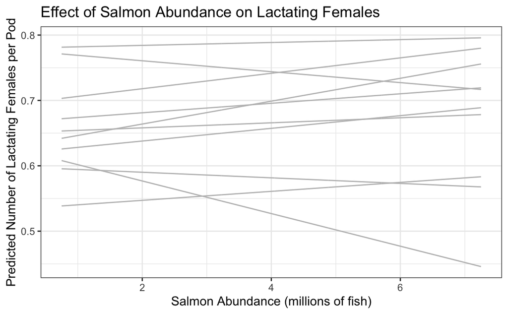

```r
# Create variables to save the lines
salmon_lines <- NULL
pod_lines <- NULL

# Create lines where one fixed effect is constant using the slopes and
# intercepts from all of the models
for (i in 1:length(result[[3]])){
  # Create a data frame of all salmon model intercepts and slopes while
  # keeping pod size constant
  lines1 <- as.data.frame(cbind(salmons = salmons)) %>%
    mutate(lact_prediction = result[[3]][i]+
             result[[1]][i]*salmons)
  lines1 <- cbind(lines1, index_model = i)
  salmon_lines <- rbind(salmon_lines, lines1)

  # Create a data frame of all pod size model intercepts and slopes while
  # keeping salmon abundance constant
  lines2 <- as.data.frame(cbind(pods = pods)) %>%
    mutate(lact_prediction = result[[3]][i]+
             result[[2]][i]*pods)
  lines2 <- cbind(lines2, index_model = i)
  pod_lines <- rbind(pod_lines, lines2)
}

# Generate plots with the models of salmon and pod effects on the predicted
# lactating females
as.data.frame(salmon_lines) %>%
  ggplot(aes(x = salmons, y = lact_prediction, group = index_model))+
  geom_line(color = "gray")+
  geom_line(aes(x = mean(salmons), y = mean(lact_prediction)), colour = "blue")+
  labs(x = "Salmon Abundance (millions of fish)",
       y ="Predicted Number of Lactating Females per Pod" ,
       title = "Effect of Salmon Abundance on Lactating Females")+
  theme_bw()
```

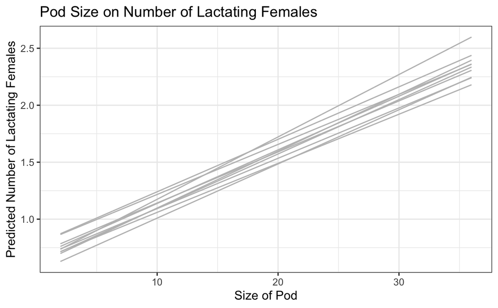

```r
as.data.frame(pod_lines) %>%
  ggplot(aes(x = pods, y = lact_prediction, group = index_model))+
  geom_line(color = "gray")+
  labs(x = "Size of Pod",
       y = "Predicted Number of Lactating Females",
       title = "Pod Size on Number of Lactating Females")+
  theme_bw()
```